# Unsupervised Learning in R

William Surles

2017-09-21

# Introduction

- Course notes from the [Unsupervised Learning in R](https://www.datacamp.com/courses/unsupervised-learning-in-r) course on DataCamp
  - Taught by Hank Roark, senior data scientist at Boeing

## Whats Covered

- Unsupervised learning in R
- Hierarchical clustering
- Dimensionality reduction with PCA
- Putting it all together with a case study

## Additional Resources

## Libraries and Data

```r
source('create_datasets.R')

library(readr)
library(dplyr)
```

# Unsupervised Learning in R

## Welcome to the course!

3 main types of machine learning:

- unsupervised learning
  - goal is to find structure in unlabeld data
  - unlabeled data is data with no targets
- supervised learning
  - regression or classification
  - goal is to predict the amount or the label
- reinforcement learning
  - a computer learns by feedback from operating in a real or synthetic environment

Two major goals:

- find homogenous subgroups within a population
  - this is called clusters
  - example: segmenting a market of consumers based on demographic features and purchasing history
  - example: find similar movies based on features of each movie and reviews of the movies
- find patterns in the features of the data
  - dimensionality reduction - a method to decrease the number of features to describe an onservation while maintining the maximum information content under the constraints of lower dimensionality

dimensionality reduction

- find patterns in the fetures of the data
- visualization of high dimensional data
  - its hard to produce good visualizations past 3 or 4 dimensions and also to consume
- pre-processing step for supervised learning

## Introduction to k-means clustering

- an algorithm used to find homogeneous subgroups in a population
- kmeans comes in base R
  - need the data
  - number of centers or groups
  - number of runs. its start by randomly assigning points to groups and you can find local minimums so running it multiple times helps you find the global min.
- you can run kmeans many times to estimate the number od subgroups when it is not known a priori

### – k-means clustering

```r
str(x)
```

```
##  num [1:300, 1:2] 3.37 1.44 2.36 2.63 2.4 ...
```

```r
head(x)
```

```
##          [,1]     [,2]
## [1,] 3.370958 1.995379
## [2,] 1.435302 2.760242
## [3,] 2.363128 2.038991
## [4,] 2.632863 2.735072
## [5,] 2.404268 1.853527
## [6,] 1.893875 1.942113
```

```r
# Create the k-means model: km.out
km.out <- kmeans(x, centers = 3, nstart = 20)

# Inspect the result
summary(km.out)
```

```
##              Length Class  Mode
## cluster      300    -none- numeric
## centers        6    -none- numeric
## totss          1    -none- numeric
## withinss       3    -none- numeric
## tot.withinss   1    -none- numeric
## betweenss      1    -none- numeric
## size           3    -none- numeric
## iter           1    -none- numeric
## ifault         1    -none- numeric
```

### – Results of kmeans()

```r
# Print the cluster membership component of the model
km.out$cluster
```

```
##   [1] 2 2 2 2 2 2 2 2 2 2 2 2 3 2 2 2 2 3 3 2 2 2 2 2 2 2 2 2 2 2 2 2 2 2 2
##  [36] 2 3 3 3 2 2 2 2 3 2 2 2 2 2 2 2 2 2 2 2 2 2 2 3 2 2 2 2 2 2 2 2 2 2 2
##  [71] 2 2 2 3 2 2 2 2 2 2 2 2 2 2 2 2 2 2 2 2 2 2 2 2 2 2 2 2 2 2 1 1 1 1 1
## [106] 1 1 1 1 1 1 1 1 1 1 1 1 1 1 1 1 1 1 1 1 1 1 1 1 1 1 1 1 1 1 1 1 1 1 1
## [141] 1 1 1 1 1 1 1 1 1 1 1 1 1 1 1 1 1 1 1 1 1 1 1 1 1 1 1 1 1 1 1 1 1 1 1
## [176] 1 1 1 1 1 1 1 1 1 1 1 1 1 1 1 1 1 1 1 1 1 1 1 1 1 1 1 1 1 1 1 1 1 1 1
## [211] 1 1 1 1 1 1 1 1 1 1 1 1 1 1 1 1 1 1 1 1 1 1 1 1 1 1 1 1 1 1 1 1 1 1 1
## [246] 1 1 1 1 1 3 3 3 3 2 3 3 3 3 3 3 3 3 3 3 3 3 3 3 3 3 3 3 3 3 2 2 3 3 2
## [281] 3 3 3 3 3 3 2 3 3 3 3 3 3 2 3 3 3 2 3 3
```

```r
# Print the km.out object
km.out
```

```
## K-means clustering with 3 clusters of sizes 150, 98, 52
##
## Cluster means:
##         [,1]        [,2]
## 1 -5.0556758  1.96991743
## 2  2.2171113  2.05110690
## 3  0.6642455 -0.09132968
##
## Clustering vector:
##   [1] 2 2 2 2 2 2 2 2 2 2 2 2 3 2 2 2 2 3 3 2 2 2 2 2 2 2 2 2 2 2 2 2 2 2 2
##  [36] 2 3 3 3 2 2 2 2 3 2 2 2 2 2 2 2 2 2 2 2 2 2 2 3 2 2 2 2 2 2 2 2 2 2 2
##  [71] 2 2 2 3 2 2 2 2 2 2 2 2 2 2 2 2 2 2 2 2 2 2 2 2 2 2 2 2 2 2 1 1 1 1 1
## [106] 1 1 1 1 1 1 1 1 1 1 1 1 1 1 1 1 1 1 1 1 1 1 1 1 1 1 1 1 1 1 1 1 1 1 1
## [141] 1 1 1 1 1 1 1 1 1 1 1 1 1 1 1 1 1 1 1 1 1 1 1 1 1 1 1 1 1 1 1 1 1 1 1
## [176] 1 1 1 1 1 1 1 1 1 1 1 1 1 1 1 1 1 1 1 1 1 1 1 1 1 1 1 1 1 1 1 1 1 1 1
## [211] 1 1 1 1 1 1 1 1 1 1 1 1 1 1 1 1 1 1 1 1 1 1 1 1 1 1 1 1 1 1 1 1 1 1 1
## [246] 1 1 1 1 1 3 3 3 3 2 3 3 3 3 3 3 3 3 3 3 3 3 3 3 3 3 3 3 3 3 2 2 3 3 2
## [281] 3 3 3 3 3 3 2 3 3 3 3 3 3 2 3 3 3 2 3 3
##
## Within cluster sum of squares by cluster:
## [1] 295.16925 148.64781  95.50625
##  (between_SS / total_SS =  87.2 %)
##
## Available components:
##
## [1] "cluster"      "centers"      "totss"        "withinss"
## [5] "tot.withinss" "betweenss"    "size"         "iter"
## [9] "ifault"
```

### – Visualizing and interpreting results of kmeans()

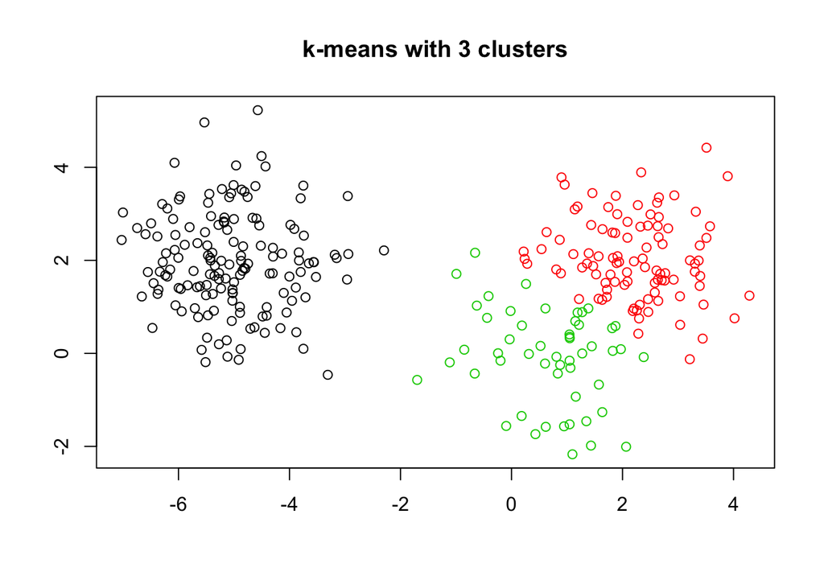

```r
# Scatter plot of x
plot(x,
  col = km.out$cluster,
  main = "k-means with 3 clusters",
  xlab = "",
  ylab = "")
```

## How kmeans() works and practical matters

Process of k-means:

- randomly assign all points to a cluster
- calculate center of each cluster
- convert points to cluster of nearest center
- if no points changed, done, otherwise repeat
- calculate new center based new points
- convert points to cluster of nearest center
- and so on

model selection:

- best outcome is based on total within cluster sum of squares
- run many times to get global optimum
- R will automaitcally take the run with the lowest total withinss

determining number of cluster

- scree plot
- look for the elbow
- find where addition on new cluster does not change best withinss much

### – Handling random algorithms

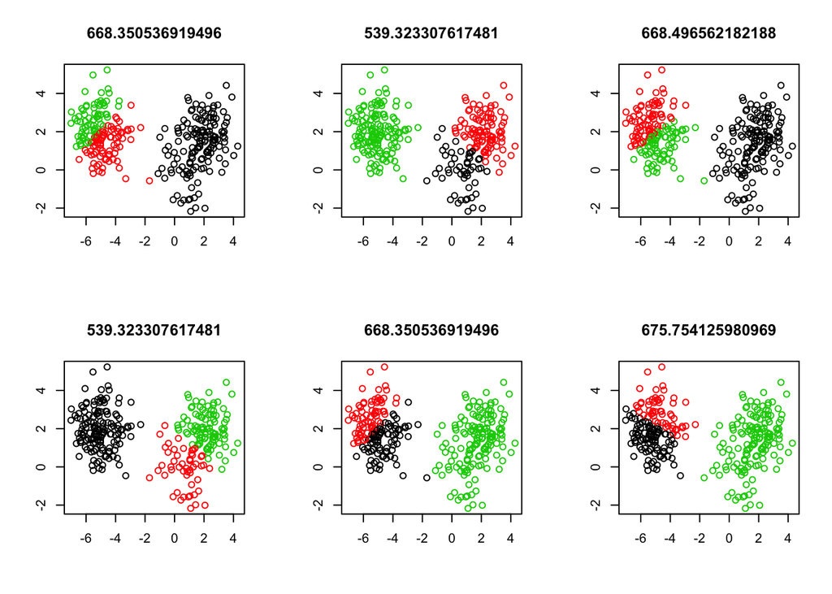

```r
# Set up 2 x 3 plotting grid
par(mfrow = c(2, 3))

# Set seed
set.seed(1)

for(i in 1:6) {
  # Run kmeans() on x with three clusters and one start
  km.out <- kmeans(x, centers = 3, nstart = 1)

  # Plot clusters
  plot(x, col = km.out$cluster,
       main = km.out$tot.withinss,
       xlab = "", ylab = "")
}
```

### – Selecting number of clusters

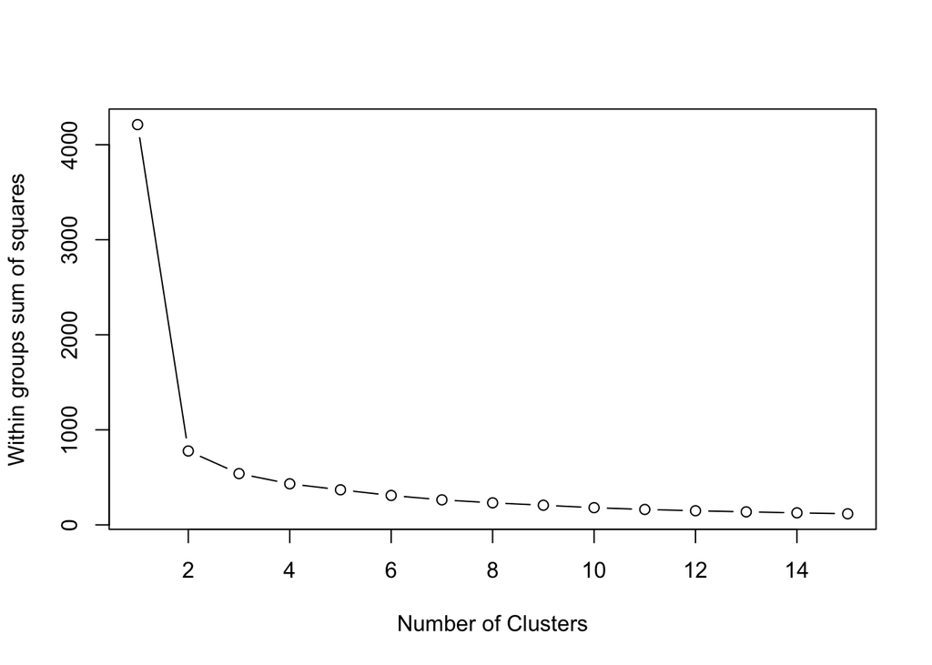

```r
# Initialize total within sum of squares error: wss
wss <- 0

# For 1 to 15 cluster centers
for (i in 1:15) {
  km.out <- kmeans(x, centers = i, nstart = 20)
  # Save total within sum of squares to wss variable
  wss[i] <- km.out$tot.withinss
}

# Plot total within sum of squares vs. number of clusters
plot(1:15, wss, type = "b",
     xlab = "Number of Clusters",
     ylab = "Within groups sum of squares")
```

```r
# Set k equal to the number of clusters corresponding to the elbow location
k <- 2
```

## Introduction to the Pokemon data

- Data hosted on kaggle [here](https://www.kaggle.com/abcsds/pokemon)
- More pokemon info [here](http://pokemondb.net/pokedex)

Data challenges:

- selecting the variable to cluster upon
- scaling the data (we will cover this)
- determining the true number of cluster
  - in real world data a nice clean elbow in the scree plot does not usually exist
- visualizing the results for interpretation

### – Practical matters: working with real data

```r
pokemon_raw <- read_csv('data/Pokemon.csv')
head(pokemon_raw)
```

```
## # A tibble: 6 x 13
##     `#`                  Name `Type 1` `Type 2` Total    HP Attack Defense
##   <int>                 <chr>    <chr>    <chr> <int> <int>  <int>   <int>
## 1     1             Bulbasaur    Grass   Poison   318    45     49      49
## 2     2               Ivysaur    Grass   Poison   405    60     62      63
## 3     3              Venusaur    Grass   Poison   525    80     82      83
## 4     3 VenusaurMega Venusaur    Grass   Poison   625    80    100     123
## 5     4            Charmander     Fire     <NA>   309    39     52      43
## 6     5            Charmeleon     Fire     <NA>   405    58     64      58
## # ... with 5 more variables: `Sp. Atk` <int>, `Sp. Def` <int>,
## #   Speed <int>, Generation <int>, Legendary <chr>
```

```r
pokemon <- pokemon_raw %>% select(6:11)
head(pokemon)
```

```
## # A tibble: 6 x 6
##      HP Attack Defense `Sp. Atk` `Sp. Def` Speed
##   <int>  <int>   <int>     <int>     <int> <int>
## 1    45     49      49        65        65    45
## 2    60     62      63        80        80    60
## 3    80     82      83       100       100    80
## 4    80    100     123       122       120    80
## 5    39     52      43        60        50    65
## 6    58     64      58        80        65    80
```

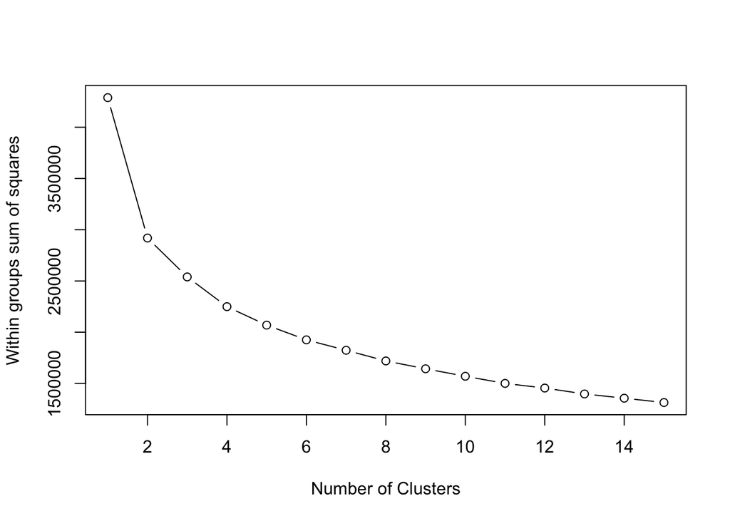

```r
# Initialize total within sum of squares error: wss
wss <- 0

# Look over 1 to 15 possible clusters
for (i in 1:15) {
  # Fit the model: km.out
  km.out <- kmeans(pokemon, centers = i, nstart = 20, iter.max = 50)
  # Save the within cluster sum of squares
  wss[i] <- km.out$tot.withinss
}

# Produce a scree plot
plot(1:15, wss, type = "b",
     xlab = "Number of Clusters",
     ylab = "Within groups sum of squares")
```

```r
# Select number of clusters
k <- 4

# Build model with k clusters: km.out
km.pokemon <- kmeans(pokemon, centers = k, nstart = 20, iter.max = 50)

# View the resulting model
km.pokemon
```

```
## K-means clustering with 4 clusters of sizes 114, 115, 288, 283
##
## Cluster means:
##         HP    Attack   Defense   Sp. Atk  Sp. Def     Speed
## 1 89.20175 121.09649  92.73684 120.45614 97.67544 100.44737
## 2 71.30435  92.91304 121.42609  63.89565 88.23478  52.36522
## 3 79.18056  81.31944  69.19097  82.01042 77.53125  80.10417
## 4 50.29682  54.03180  51.62898  47.90459 49.15548  49.74912
##
## Clustering vector:
##   [1] 4 3 3 1 4 3 3 1 1 4 3 3 1 4 4 3 4 4 3 3 4 4 3 1 4 3 4 3 4 3 4 3 4 2 4
##  [36] 4 3 4 4 3 4 3 4 3 4 3 4 3 4 3 3 4 2 4 3 4 3 4 3 4 3 4 3 4 1 4 4 3 4 3
##  [71] 3 1 4 3 2 4 3 3 4 3 4 2 2 3 3 4 2 2 4 3 4 4 3 4 3 4 3 4 2 4 3 3 1 2 4
## [106] 3 4 2 4 3 4 3 4 2 3 2 4 4 2 4 2 3 3 3 1 4 3 4 3 4 3 3 3 3 3 3 2 1 3 4
## [141] 3 1 3 4 4 3 3 1 3 4 2 4 2 3 1 3 1 1 1 4 3 1 1 1 1 1 4 3 3 4 3 3 4 3 3
```

[output cut: 28 more lines]

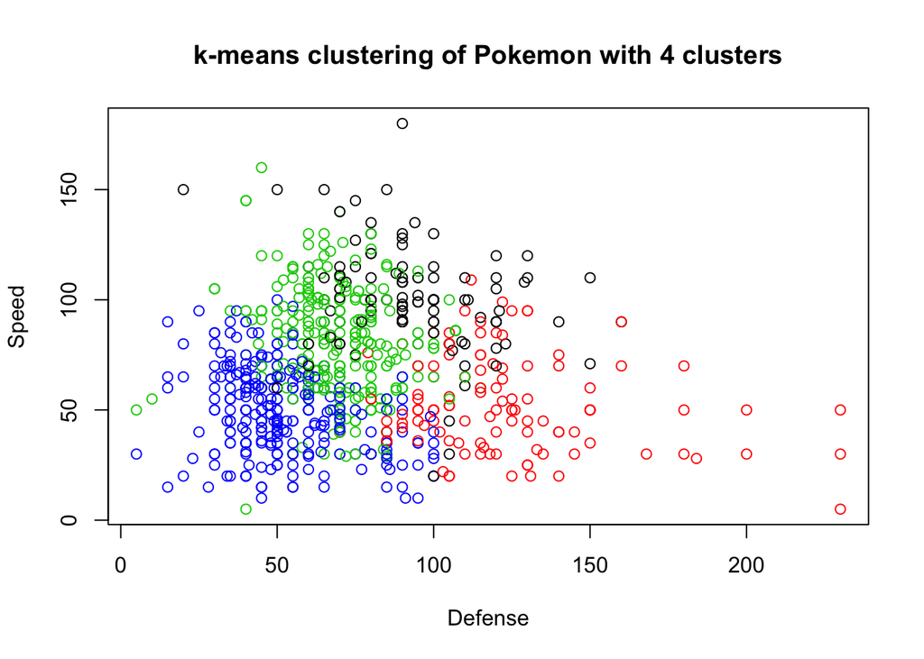

```r
# Plot of Defense vs. Speed by cluster membership
plot(pokemon[, c("Defense", "Speed")],
     col = km.pokemon$cluster,
     main = paste("k-means clustering of Pokemon with", k, "clusters"),
     xlab = "Defense", ylab = "Speed")
```

# Hierarchical clustering

## Introduction to hierarchical clustering

- Typically used when the number of clusters in not known a head of time
- Two approaches. bottum up and top down. we will focus on bottum up
- process
  - assign each point to its own cluster
  - joing the two closesest custers/points into a new cluster
  - keep going until there is one cluster
  - they way you calculate the distance between clusters is a paramater and will be covered later
- we have to first calculate the euclidean distance between all points (makes a big matriz) using the `dist()` function
  - this is passed into the `hclust()` function

### – Hierarchical clustering with results

```r
head(x)
```

```
##          [,1]     [,2]
## [1,] 3.370958 1.995379
## [2,] 1.435302 2.760242
## [3,] 2.363128 2.038991
## [4,] 2.632863 2.735072
## [5,] 2.404268 1.853527
## [6,] 1.893875 1.942113
```

```r
# Create hierarchical clustering model: hclust.out
hclust.out <- hclust(dist(x))

# Inspect the result
summary(hclust.out)
```

```
##             Length Class  Mode
## merge       598    -none- numeric
## height      299    -none- numeric
## order       300    -none- numeric
## labels        0    -none- NULL
## method        1    -none- character
## call          2    -none- call
## dist.method   1    -none- character
```

## Selecting number of clusters

- you can build a dendrogram of the distances between points
- then you either pick the number of clusters or the height (aka distance) that you want to split the cluster.
  - think of this as drawing a horizontal line across the dendrogram
- the `cutree()` function in R lets you split the hierarchical clusters into set clusters by number or by distance (height)

### – Cutting the tree

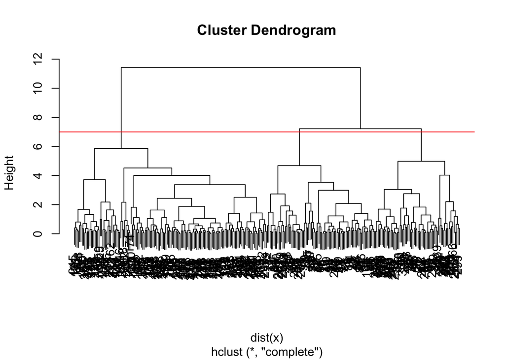

```r
plot(hclust.out)
abline(h = 7, col = "red")
```

```r
# Cut by height
cutree(hclust.out, h = 7)
```

```
##   [1] 1 1 1 1 1 1 1 1 1 1 1 1 2 1 1 1 2 2 2 1 1 2 1 1 1 2 1 2 1 2 1 1 1 2 1
##  [36] 2 2 2 2 1 1 1 1 2 2 1 1 1 2 1 1 2 1 1 1 1 1 1 2 1 2 1 1 1 2 1 1 1 1 1
##  [71] 1 1 1 2 1 1 1 1 2 1 1 1 1 1 2 1 1 1 1 1 1 2 1 1 2 1 2 2 1 1 3 3 3 3 3
## [106] 3 3 3 3 3 3 3 3 3 3 3 3 3 3 3 3 3 3 3 3 3 3 3 3 3 3 3 3 3 3 3 3 3 3 3
## [141] 3 3 3 3 3 3 3 3 3 3 3 3 3 3 3 3 3 3 3 3 3 3 3 3 3 3 3 3 3 3 3 3 3 3 3
## [176] 3 3 3 3 3 3 3 3 3 3 3 3 3 3 3 3 3 3 3 3 3 3 3 3 3 3 3 3 3 3 3 3 3 3 3
## [211] 3 3 3 3 3 3 3 3 3 3 3 3 3 3 3 3 3 3 3 3 3 3 3 3 3 3 3 3 3 3 3 3 3 3 3
## [246] 3 3 3 3 3 2 2 2 2 1 2 2 2 2 2 1 1 2 2 2 2 1 2 2 2 2 2 2 2 2 1 2 2 1 1
## [281] 1 2 2 2 2 2 1 2 2 2 2 2 2 1 2 2 2 1 2 2
```

```r
# Cut by number of clusters
cutree(hclust.out, k = 3)
```

```
##   [1] 1 1 1 1 1 1 1 1 1 1 1 1 2 1 1 1 2 2 2 1 1 2 1 1 1 2 1 2 1 2 1 1 1 2 1
##  [36] 2 2 2 2 1 1 1 1 2 2 1 1 1 2 1 1 2 1 1 1 1 1 1 2 1 2 1 1 1 2 1 1 1 1 1
##  [71] 1 1 1 2 1 1 1 1 2 1 1 1 1 1 2 1 1 1 1 1 1 2 1 1 2 1 2 2 1 1 3 3 3 3 3
## [106] 3 3 3 3 3 3 3 3 3 3 3 3 3 3 3 3 3 3 3 3 3 3 3 3 3 3 3 3 3 3 3 3 3 3 3
## [141] 3 3 3 3 3 3 3 3 3 3 3 3 3 3 3 3 3 3 3 3 3 3 3 3 3 3 3 3 3 3 3 3 3 3 3
## [176] 3 3 3 3 3 3 3 3 3 3 3 3 3 3 3 3 3 3 3 3 3 3 3 3 3 3 3 3 3 3 3 3 3 3 3
## [211] 3 3 3 3 3 3 3 3 3 3 3 3 3 3 3 3 3 3 3 3 3 3 3 3 3 3 3 3 3 3 3 3 3 3 3
## [246] 3 3 3 3 3 2 2 2 2 1 2 2 2 2 2 1 1 2 2 2 2 1 2 2 2 2 2 2 2 2 1 2 2 1 1
## [281] 1 2 2 2 2 2 1 2 2 2 2 2 2 1 2 2 2 1 2 2
```

## Clustering linkage and practical matters

- 4 methods to measure distance between clusters
  - `complete`: pairwise similarty between all observations in cluster 1 and 2, uses largest of similarities
  - `single`: same as above but uses the smallest of similarities
  - `average`: same as above but uses average of similarities
  - `centroid`: finds centroid of cluster 1 and 2, uses similarity between tow centroids
- rule of thumb
  - `complete` and average produce more balanced treess and are more commonly used
  - `single` fuses observations in one at a time and produces more unblanced trees
  - `centroid` can create inversion where clusters are put below single values. its not used often
- practical matters
  - data needs to be scaled so that features have the same mean and standard deviation
  - normalized features have a mean of zero and a sd of one

### – Linkage methods

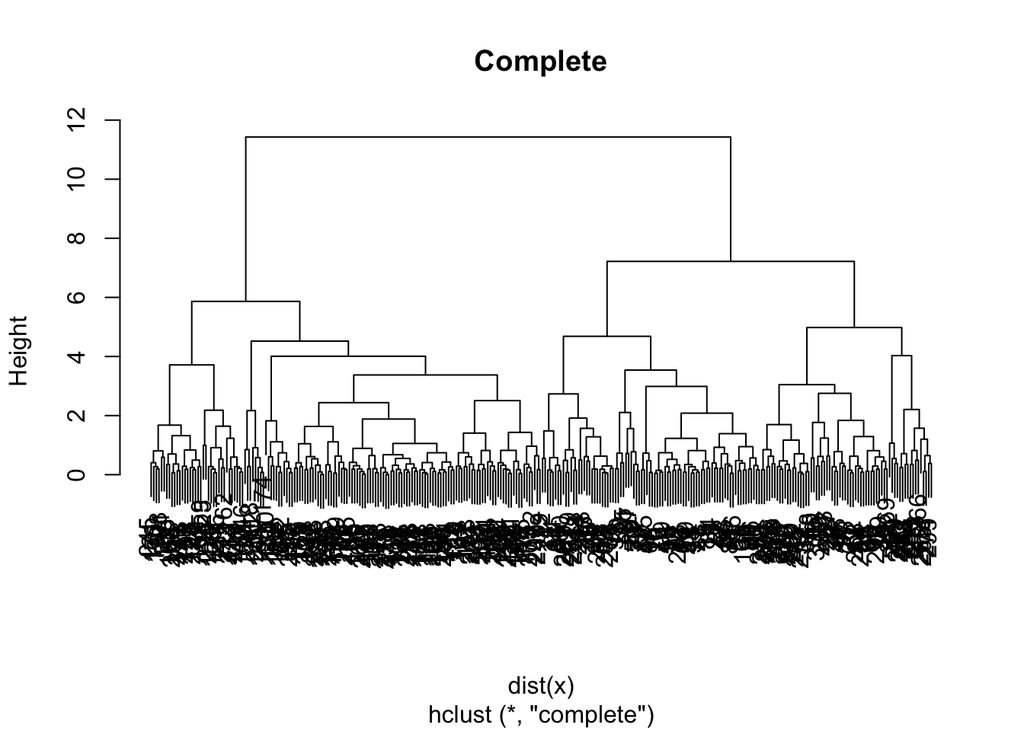

```r
# Cluster using complete linkage: hclust.complete
hclust.complete <- hclust(dist(x), method = "complete")

# Cluster using average linkage: hclust.average
hclust.average <- hclust(dist(x), method = "average")

# Cluster using single linkage: hclust.single
hclust.single <- hclust(dist(x), method = "single")

# Plot dendrogram of hclust.complete
plot(hclust.complete, main = "Complete")
```

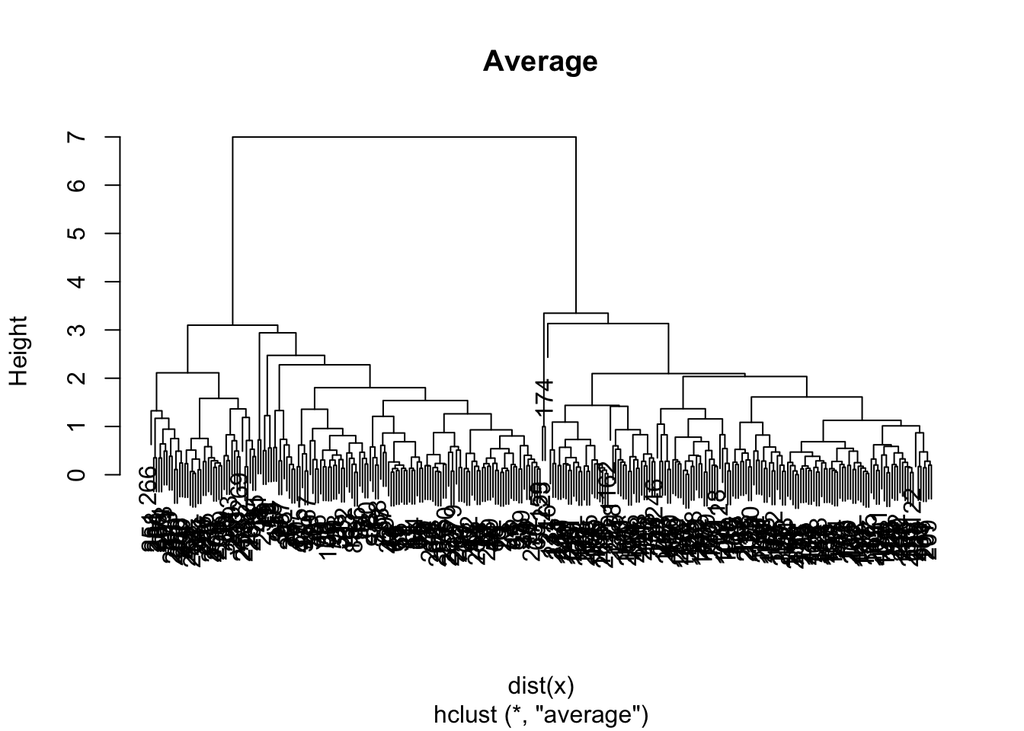

```r
# Plot dendrogram of hclust.average
plot(hclust.average, main = "Average")
```

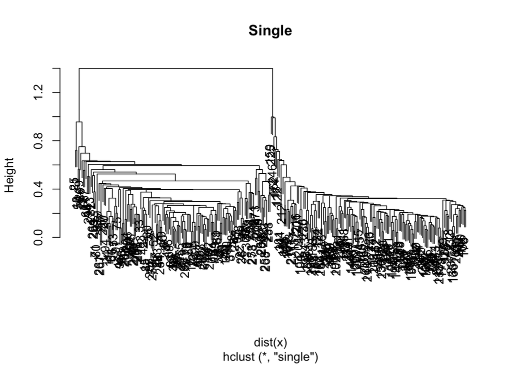

```r
# Plot dendrogram of hclust.single
plot(hclust.single, main = "Single")
```

### – Practical matters: scaling

```r
# View column means
colMeans(pokemon)
```

```
##       HP   Attack  Defense  Sp. Atk  Sp. Def    Speed
## 69.25875 79.00125 73.84250 72.82000 71.90250 68.27750
```

```r
# View column standard deviations
apply(pokemon, 2, sd)
```

```
##       HP   Attack  Defense  Sp. Atk  Sp. Def    Speed
## 25.53467 32.45737 31.18350 32.72229 27.82892 29.06047
```

```r
# Scale the data
pokemon.scaled <- scale(pokemon)

# Create hierarchical clustering model: hclust.pokemon
hclust.pokemon <- hclust(dist(pokemon.scaled), method = "complete")
```

### – Comparing kmeans() and hclust()

```r
# Apply cutree() to hclust.pokemon: cut.pokemon
cut.pokemon <- cutree(hclust.pokemon, k = 3)

# Compare methods
table(km.pokemon$cluster, cut.pokemon)
```

```
##    cut.pokemon
##       1   2   3
##   1 114   0   0
##   2 114   0   1
##   3 277  11   0
##   4 283   0   0
```

## Review of hierarchical clustering

# Dimensionality reduction with PCA

## Introduction to PCA

### – PCA using prcomp()

### – Results of PCA

### – Additional results of PCA

## Visualizing and interpreting PCA results

### – Interpreting biplots (1)

### – Interpreting biplots (2)

### – Variance explained

### – Visualize variance explained

## Practical issues with PCA

### – Practical issues: scaling

## Additional uses of PCA and wrap-up

# Putting it all together with a case sudy

## Introduction to the case study

### – Preparing the data

### – Exploratory data analysis

### – Performing PCA

### – Interpreting PCA results

### – Variance explained

### – Communicating PCA results

## PCA review and next steps

### – Hierarchical clustering of case data

### – Results of hierarchical clustering

### – Selecting number of clusters

### – k-means clustering and comparing results

### – Clustering on PCA results

## Wrap-up and review